# Wellness Case Study

### Relationship between total time in bed and total minutes asleep

Notes: Show correlation between time in bed and time asleep

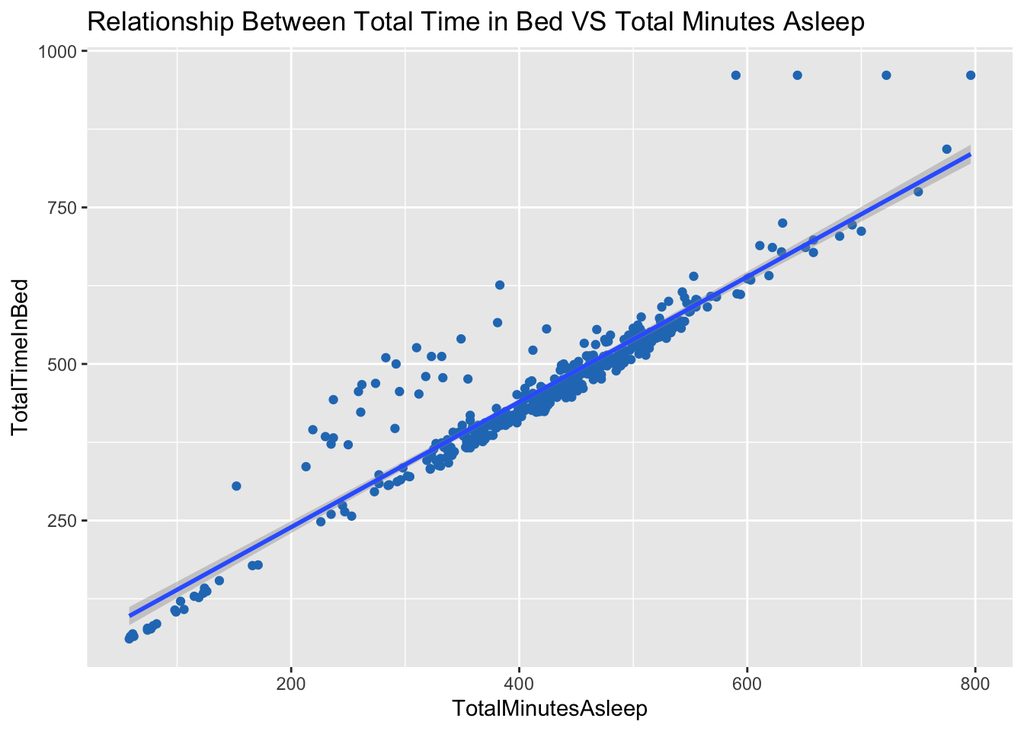

```r
ggplot(data = daily_sleep, aes(x= TotalMinutesAsleep, y=  TotalTimeInBed)) +
  geom_point(shape= "circle", color = "#277BC0") +
  stat_smooth(method = lm) +
  labs(title = "Relationship Between Total Time in Bed VS Total Minutes Asleep")
```

There is a positive correlation between total time in bed and total minutes asleep

## Act

In the final step, we will be delivering our insights and providing recommendations based on our analysis. Here, we revisit our business questions and share with our high-level business recommendations.

### How could these trends apply to Bellabeat customers?

Products developed are focused on providing women with their health, habit and fitness data and encouraging them to understand their current habits and make healthy decisions. These common trends surrounding health and fitness can very well be applied to Bellabeat customers. Bellabeat could easily market these products to costumers by telling them smart-devices could help them start their journey by measuring and tracking all health metrics and the benefit to their health and lifestyle.

### How could these trends help influence Bellabeat marketing strategy?

It is well documented that moderate-to-vigorous physical activity is protective against chronic disease and self-monitoring of behavior is one of the most robust behavior-change techniques available.

Bellabeat marketing team can:

- Encourage users by educating and equipping them with knowledge about fitness benefits, suggest different types of exercise such as a simple 15 minutes exercise on weekday and a more intense exercise on weekend
- Prompt notification to encourage users to exercise. By marketing these devices to consumers, Bellabeat provides a unique opportunity for individuals to change their behavior, become more physically active and increase their life expectancy
- Prompt notification to encourage users to have atleast 7 hours of sleep as this is crucial for a healthy lifestyle